# MachineLearning_Classification_paudyal

# Banknote authentication

This dataset presents an example of classification problem (authentic vs. counterfeit bank notes) using continuous predictors derived from image processing. More details about underlying data can be found in corresponding [dataset description](http://archive.ics.uci.edu/ml/datasets/banknote+authentication) at UCI ML website.

Loading the data, `data_banknote_authentication.txt` with the following attributes. The first $\textbf{four attributes}$ are used as $\textbf{predictors}$ to classify the outcome (authenic or counterfeit) and is presented by the $\textbf{fifth attribute as "Class"}$:

1.$\textbf{Var.W}$ : variance of Wavelet Transformed image (continuous)

2.$\textbf{Skew.W}$ : skewness of Wavelet Transformed image (continuous)

3.$\textbf{Curt.W}$ : curtosis of Wavelet Transformed image (continuous)

4.$\textbf{Entropy}$ : entropy of image (continuous)

5.$\textbf{Class}$ : class (integer)

```r
bank.N <- read.table("data_banknote_authentication.txt",sep=",")
colnames(bank.N) <- c("Var.W","Skew.W","Curt.W","Entropy", "Class")
# Checking the "Predictors" summary
summary(bank.N[,1:4])
```

```
##      Var.W             Skew.W            Curt.W           Entropy
##  Min.   :-7.0421   Min.   :-13.773   Min.   :-5.2861   Min.   :-8.5482
##  1st Qu.:-1.7730   1st Qu.: -1.708   1st Qu.:-1.5750   1st Qu.:-2.4135
##  Median : 0.4962   Median :  2.320   Median : 0.6166   Median :-0.5867
##  Mean   : 0.4337   Mean   :  1.922   Mean   : 1.3976   Mean   :-1.1917
##  3rd Qu.: 2.8215   3rd Qu.:  6.815   3rd Qu.: 3.1793   3rd Qu.: 0.3948
##  Max.   : 6.8248   Max.   : 12.952   Max.   :17.9274   Max.   : 2.4495
```

```r
# detecting number of ZEROs versus ONEs on the Outcome, "Class" attribute
bank.N$Class <- factor(bank.N$Class)
summary(bank.N[,5])
```

```
##   0   1
## 762 610
```

```r
# The total number of Zeros and Ones are accounted for: 762 + 610 = 1372, all the data has been classified as Authenic or Counterfeit.
dim(bank.N)
```

```
## [1] 1372    5
```

# Logistic Regression

Fit logistic regression model of the class attribute using the four features as predictors in the model. Based on on the report from the fitting, which features seems to be significantly related to our “Class”, a categorical outcome. Use prediction for the entire data (no splitting for train/test). How does the prediction result compare to our “Class” (i.e. confusion Table).

$\textbf{Logistic Regression Model}$

```r
L.R.fit = glm(formula = Class ~ ., family = "binomial", data = bank.N)
summary(L.R.fit)
```

```
##
## Call:
## glm(formula = Class ~ ., family = "binomial", data = bank.N)
##
## Deviance Residuals:
##      Min        1Q    Median        3Q       Max
## -1.70001   0.00000   0.00000   0.00029   2.24614
##
## Coefficients:
##             Estimate Std. Error z value Pr(>|z|)
## (Intercept)   7.3218     1.5589   4.697 2.64e-06 ***
## Var.W        -7.8593     1.7383  -4.521 6.15e-06 ***
## Skew.W       -4.1910     0.9041  -4.635 3.56e-06 ***
## Curt.W       -5.2874     1.1612  -4.553 5.28e-06 ***
## Entropy      -0.6053     0.3307  -1.830   0.0672 .
## ---
## Signif. codes:  0 '***' 0.001 '**' 0.01 '*' 0.05 '.' 0.1 ' ' 1
##
## (Dispersion parameter for binomial family taken to be 1)
##
##     Null deviance: 1885.122  on 1371  degrees of freedom
## Residual deviance:   49.891  on 1367  degrees of freedom
## AIC: 59.891
##
## Number of Fisher Scoring iterations: 12
```

Summary of the logistic regression is shown above.

The $\textbf{confusion matrix}$ of our logistic model of the entire dataset is given below

```r
predict <- predict(L.R.fit, type = 'response')
#confusion matrix
conf_matrix = table(bank.N[,"Class"], predict > 0.5)
conf_matrix
```

```
##
##     FALSE TRUE
##   0   757    5
##   1     6  604
```

The confusion matrix from the logistic regression gives the good prediction of bank note.

Plotting the link and response of the above prediction.

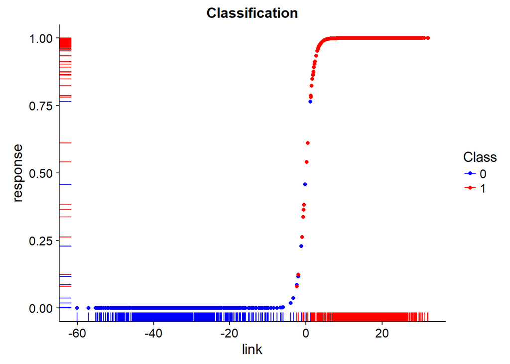

```r
L.R.link <- predict(L.R.fit,type="link")
L.R.response <- predict(L.R.fit,type="response")



class_predict <- data.frame(link=L.R.link,
                         response=L.R.response,
                         Class = bank.N$Class,
                         stringsAsFactors=FALSE)


  ggplot(class_predict, aes(x=link, y=response, col=Class)) +
  scale_color_manual(values=c("blue", "red")) +
  geom_point() +
  geom_rug() +
  ggtitle("Classification")
```

Calculate the error rate and explain if this is a training or test error? Also calculate the sensitivity and specificity.

```r
logr_accuracy = sum(diag(conf_matrix))/sum(conf_matrix)
logr_accuracy
```

```
## [1] 0.9919825
```

```r
logr_error = 1 - logr_accuracy
logr_error
```

```
## [1] 0.008017493
```

```r
sensitivity = conf_matrix[2,2]/sum(conf_matrix[2,])
sensitivity
```

```
## [1] 0.9901639
```

```r
specificity = conf_matrix[1,1]/sum(conf_matrix[1,])
specificity
```

```
## [1] 0.9934383
```

The $\textbf{Logistic regression model}$ shows the accuracy of 99.19% and error of 0.80%. The specificity is 99.34% and sensitivity is 99.01%

# LDA and QDA (package: MASS)

Fit LDA and QDA model on the entire dataset and calculate confusion matrix, (training) error rate, sensitivity and specificity for each. Compare them to those of logistic regression. Describe the results.

```r
LDA.fit <- lda(Class~., data=bank.N)
summary(LDA.fit)
```

```
##         Length Class  Mode
## prior   2      -none- numeric
## counts  2      -none- numeric
## means   8      -none- numeric
## scaling 4      -none- numeric
## lev     2      -none- character
## svd     1      -none- numeric
## N       1      -none- numeric
## call    3      -none- call
## terms   3      terms  call
## xlevels 0      -none- list
```

```r
LDA.pred <- predict(LDA.fit, bank.N)
c_mat <- table(LDA.pred$class, bank.N$Class)
c_mat
```

```
##
##       0   1
##   0 730   0
##   1  32 610
```

Confusion matrix for LDA is shown above. False Negative is really high. It gives us good 1’s prediction.

$\textbf{Linear Discriminant Model}$

```r
lda_accuracy <- confusionMatrix(c_mat)$overall[[1]]
lda_accuracy
```

```
## [1] 0.9766764
```

```r
lda_error <- 1-lda_accuracy
lda_error
```

```
## [1] 0.02332362
```

```r
lda_sens <- sensitivity(c_mat)
lda_sens
```

```
## [1] 0.9580052
```

```r
lda_spec <- specificity(c_mat)
lda_spec
```

```
## [1] 1
```

The accuracy of our prediction is 97.66% which gives us $\textbf{error rate}$ of 2.33%. The sensitivity is 95.80% and specificity is 100%.

```r
QDA.fit <- qda(Class~., data=bank.N)
QDA.pred <- predict(QDA.fit, bank.N)
summary(QDA.pred)
```

```
##           Length Class  Mode
## class     1372   factor numeric
## posterior 2744   -none- numeric
```

Summary of the QDA predict is shown above

```r
c_mat = table(QDA.pred$class, bank.N$Class)
c_mat
```

```
##
##       0   1
##   0 742   0
##   1  20 610
```

The confusion matrix of shows high false negative value. The model did great predction on 1s.

```r
qda_accuracy <- confusionMatrix(c_mat)$overall[[1]]
as.matrix(c_mat)
```

```
##
##       0   1
##   0 742   0
##   1  20 610
```

```r
qda_accuracy
```

```
## [1] 0.9854227
```

```r
qda_error <- 1-qda_accuracy
qda_error
```

```
## [1] 0.01457726
```

```r
qda_sens <- sensitivity(c_mat)
qda_sens
```

```
## [1] 0.9737533
```

```r
qda_spec <- specificity(c_mat)
qda_spec
```

```
## [1] 1
```

# k-NN (package: Class)

Using `knn`, fit k-NN classifiers for the entire dataset and calculate confusion matrix, (training) error rate, sensitivity/specificity for k = 1 : 10. Compare them to corresponding results from logistic regression, LDA and QDA. Describe results of this comparison. Discuss your low training error rate for k-NN at k=1!

$\textbf{K-Nearest Neighbour(k-NN)}$

```r
bank.N_tr.tor <- bank.N[,5]
bank.N_tr <- scale(bank.N[,c(1,2,3,4)])

accuracy <- c()
for (n.K in c(1:10)) {
  #knn fit for the given data
  knn.fit <- knn(train=bank.N_tr, test=bank.N_tr, cl=bank.N_tr.tor, k=n.K)

  c_mat <- confusionMatrix(bank.N_tr.tor, knn.fit)
  if(n.K == 1){
    c_mat_k.1 <- table(bank.N_tr.tor, knn.fit)
  }

  print(paste("Value of K:", n.K))
  print(as.matrix(c_mat))
  accuracy <- append(accuracy, (c_mat$overall[[1]] * 100))
}
```

```
## [1] "Value of K: 1"
##     0   1
## 0 762   0
## 1   0 610
## [1] "Value of K: 2"
##     0   1
## 0 760   2
## 1   0 610
## [1] "Value of K: 3"
##     0   1
## 0 760   2
## 1   0 610
## [1] "Value of K: 4"
##     0   1
## 0 760   2
```

[output cut: 25 more lines]

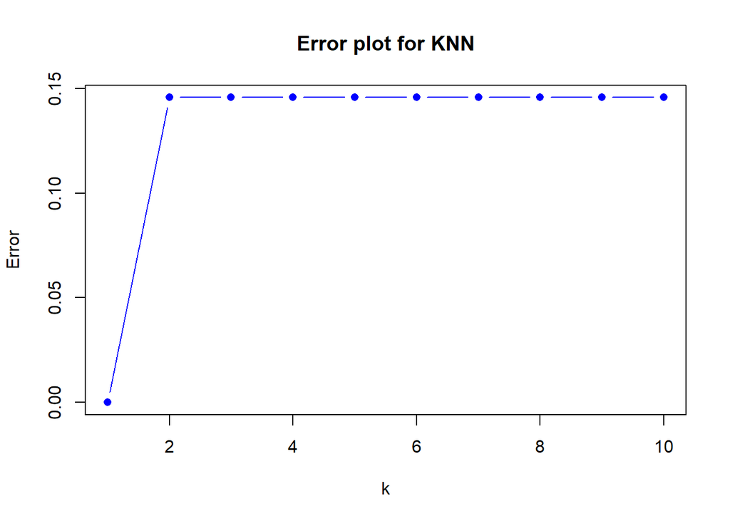

```r
Error = 100 - accuracy
plot(Error, type = 'b', main = "Error plot for KNN", pch = 16,col = 20, xlab = "k")
```

# TEST errors

Now compare of logistic regression, LDA, QDA and k-NN. Using re-sampling approach, obtain test error as well as sensitivity and speciï¬city for each of these methods (logistic regression, LDA, QDA, k-NN with k = 1, 3, 5, 11, 21, 51, 101 ). Present your results in the form of BoxPlots, compare test error, sensitivity, and specificity for all these methods and discuss their relative performance.

$\textbf{Comparision of logistic regression, LDA, QDA and k-NN}$ Comparing the error rate, sensitivity and specificity of the test data.

```r
ntry <- 7

logr_error_rate <- NULL
qda_error_rate <- NULL
lda_error_rate <- NULL
knn_error_rate <- NULL


logr_sens_rate <- NULL
qda_sens_rate <- NULL
lda_sens_rate <- NULL
knn_sens_rate <- NULL

logr_spec_rate <- NULL
qda_spec_rate <- NULL
lda_spec_rate <- NULL
knn_spec_rate <-NULL


for(i in 1:ntry)
{
tr_idx  <- sample(nrow(bank.N),round(0.8*nrow(bank.N),digits=0)); length(tr_idx)
ts_idx  <- -tr_idx
bank.N_tr <- bank.N[tr_idx, ]; dim(bank.N_tr)
bank.N_ts <- bank.N[ts_idx, ]; dim(bank.N_ts)
bank.N_tr_f.tor <- bank.N[tr_idx, "Class"]
bank.N_ts_f.tor <- bank.N[ts_idx, "Class"]

# MODELS

#Logistic Regression Model
L.R.fit = glm(formula = Class ~ ., family = "binomial", data = bank.N_tr)
L.R.prob <- predict(L.R.fit,newdata=bank.N_ts,type="response")
L.R.response <- predict(L.R.fit,newdata=bank.N_ts,type="response")

conf_matrix = table(bank.N_ts[,"Class"], L.R.response > 0.5)
#calculate the error rate, sensitivity and specificity for logistic regresstion

logr_test_accuracy = sum(diag(conf_matrix))/sum(conf_matrix)
logr_test_error = 1 - logr_test_accuracy
logr_test_sensitivity = conf_matrix[2,2]/sum(conf_matrix[2,])
logr_test_specificity = conf_matrix[1,1]/sum(conf_matrix[1,])

logr_error_rate <- rbind(logr_error_rate,logr_test_error)
logr_sens_rate <- rbind(logr_sens_rate,logr_test_sensitivity)
logr_spec_rate <- rbind(logr_spec_rate,logr_test_specificity)

#LDA Model
LDA.fit <- lda(Class~., data=bank.N_tr)
LDA.pred <- predict(LDA.fit, bank.N_ts)

c_mat <- table(LDA.pred$class, bank.N_ts$Class)

#calculate the error rate, sensitivity and specificity for LDA
LDA_test_accuracy<-accuracy <- confusionMatrix(c_mat)$overall[[1]]
LDA_test_error <- 1-LDA_test_accuracy
LDA_test_sensitivity <- sensitivity(c_mat)
LDA_test_specificity <- specificity(c_mat)

lda_error_rate <- rbind(lda_error_rate,LDA_test_error)
lda_sens_rate <- rbind(lda_sens_rate,LDA_test_sensitivity)
lda_spec_rate <- rbind(lda_spec_rate,LDA_test_specificity)

#QDA Model
QDA.fit <- qda(Class~., data=bank.N_tr)
QDA.pred <- predict(QDA.fit, bank.N_ts)

c_mat = table(QDA.pred$class, bank.N_ts$Class)

#calculate the error rate, sensitivity and specificity for QDA
QDA_test_accuracy<-accuracy <- confusionMatrix(c_mat)$overall[[1]]
QDA_test_error <- 1-QDA_test_accuracy
QDA_test_sensitivity <- sensitivity(c_mat)
QDA_test_specificity <- specificity(c_mat)

qda_error_rate <- rbind(qda_error_rate,QDA_test_error)
qda_sens_rate <- rbind(qda_sens_rate,QDA_test_sensitivity)
qda_spec_rate <- rbind(qda_spec_rate,QDA_test_specificity)
}
```

The following is the test error rate for KNN

```r
accuracy <- c()
for (n.K in c(1, 3, 5, 11, 21, 51, 101)) {
  #knn fit for the given data
  knn.fit <- knn(train=bank.N_tr, test=bank.N_ts, cl=bank.N_tr_f.tor, k=n.K)

  conf_matrix <- table(bank.N_ts_f.tor, knn.fit)

  knn_test_accuracy = sum(diag(conf_matrix))/sum(conf_matrix)
  knn_test_accuracy

  knn_test_error = 1 - knn_test_accuracy
  knn_test_error

  knn_test_sensitivity = conf_matrix[2,2]/sum(conf_matrix[2,])
  knn_test_sensitivity

  knn_test_specificity = conf_matrix[1,1]/sum(conf_matrix[1,])
  knn_test_specificity

###
  knn_error_rate <- rbind(knn_error_rate,knn_test_error)
  knn_sens_rate <- rbind(knn_sens_rate,knn_test_sensitivity)
  knn_spec_rate <- rbind(knn_spec_rate,knn_test_specificity)

}
```

$\textbf{Comparision table}$ for error rate, sensitivity and specificity of the test.

```r
error <- data.frame(logr_error_rate = logr_error_rate[,1] * 100, lda_error_rate = lda_error_rate[,1] * 100, qda_error_rate = qda_error_rate[,1]*100, knn_error_rate = knn_error_rate[,1]*100)
sensitivity <- data.frame(logr_sens_rate = logr_sens_rate[,1] * 100, lda_sens_rate = lda_sens_rate[,1] * 100, qda_sens_rate = qda_sens_rate[,1]*100, knn_sens_rate = knn_sens_rate[,1]*100)
specificity <- data.frame(logr_spec_rate = logr_spec_rate[,1] * 100, lda_spec_rate = lda_spec_rate[,1] * 100, qda_spec_rate = qda_spec_rate[,1]*100, knn_spec_rate = knn_spec_rate[,1]*100)

error
```

```
##   logr_error_rate lda_error_rate qda_error_rate knn_error_rate
## 1       0.7299270       1.824818       0.729927       0.000000
## 2       0.0000000       1.094891       0.000000       0.000000
## 3       0.7299270       1.824818       1.459854       0.000000
## 4       1.4598540       1.824818       1.094891       0.000000
## 5       0.3649635       2.189781       1.824818       0.000000
## 6       0.0000000       1.824818       1.094891       0.729927
## 7       2.1897810       2.189781       1.094891       1.459854
```

```r
sensitivity
```

```
##   logr_sens_rate lda_sens_rate qda_sens_rate knn_sens_rate
## 1       99.09910      96.93252      98.77301      100.0000
## 2      100.00000      97.95918     100.00000      100.0000
## 3       99.04762      97.04142      97.63314      100.0000
## 4       98.36066      96.71053      98.02632      100.0000
## 5      100.00000      95.86207      96.55172      100.0000
## 6      100.00000      96.35036      97.81022      100.0000
## 7       96.85039      95.91837      97.95918       99.2126
```

```r
specificity
```

```
##   logr_spec_rate lda_spec_rate qda_spec_rate knn_spec_rate
## 1       99.38650           100           100     100.00000
## 2      100.00000           100           100     100.00000
## 3       99.40828           100           100     100.00000
## 4       98.68421           100           100     100.00000
## 5       99.31034           100           100     100.00000
## 6      100.00000           100           100      98.63946
## 7       98.63946           100           100      97.95918
```

$\textbf{Box plot comparision}$ Comparision of Logistic Regresssion, LDA, QDA and K-NN test result is show in box plot below

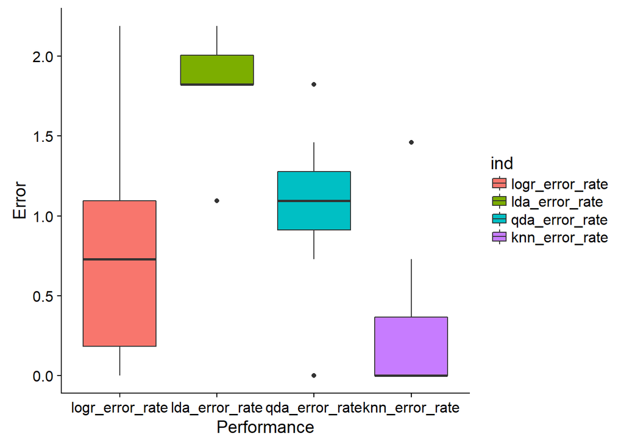

```r
ggplot(stack(error), aes(x = ind, y = values, fill = ind)) +
  geom_boxplot() +
  ylab("Error") +
  xlab("Performance")
```

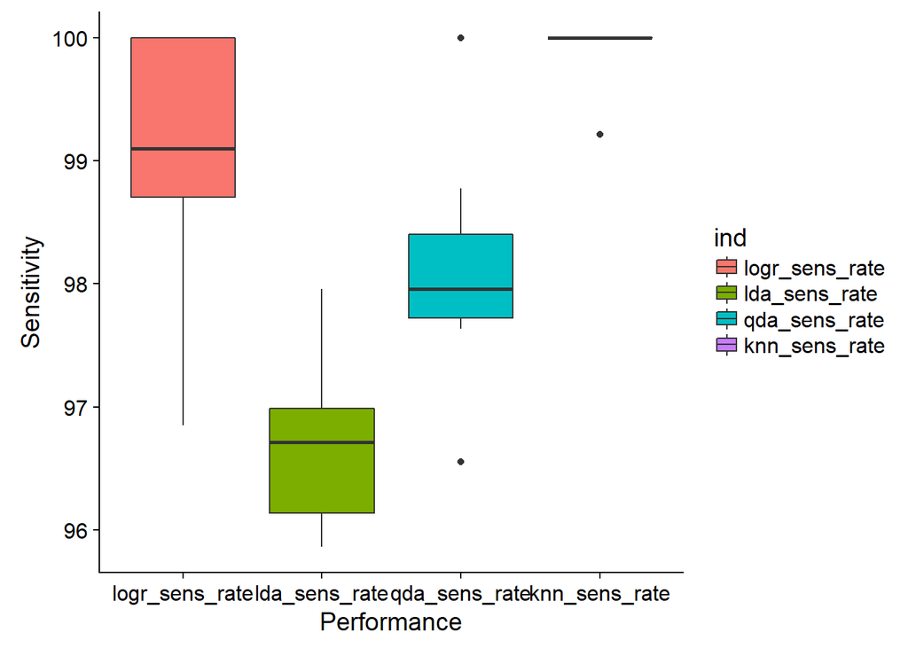

```r
ggplot(stack(sensitivity), aes(x = ind, y = values, fill = ind)) +
  geom_boxplot() +
  ylab("Sensitivity")+
  xlab("Performance")
```

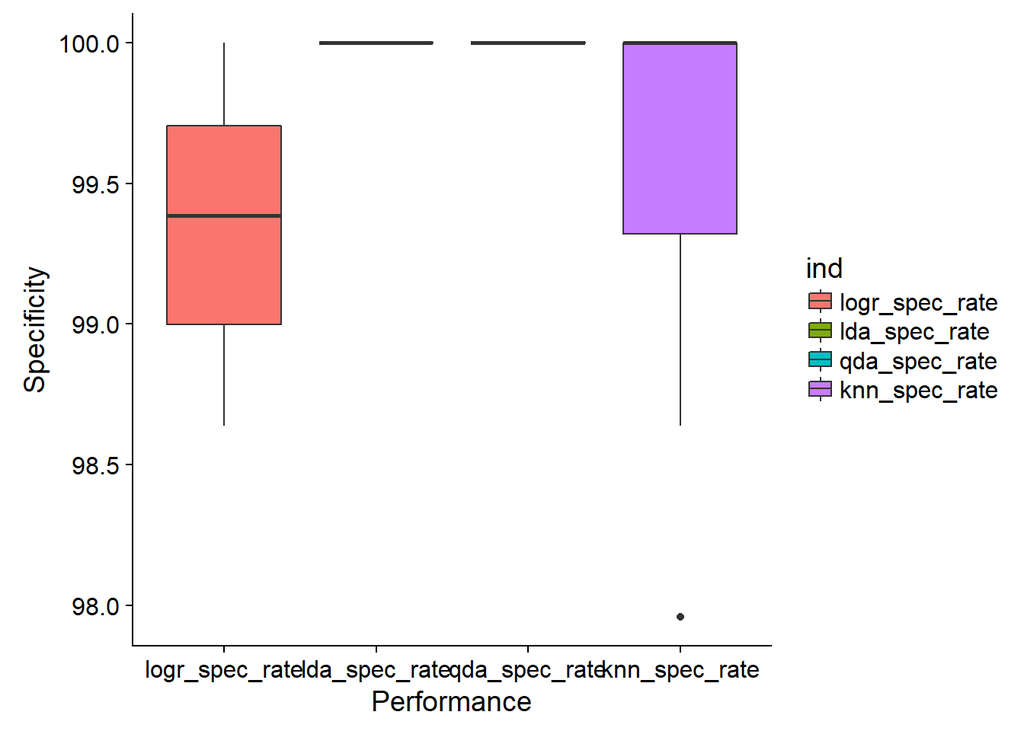

```r
ggplot(stack(specificity), aes(x = ind, y = values, fill = ind)) +
  geom_boxplot() +
  ylab("Specificity")+
  xlab("Performance")
```

The above plot show that KNN did a great predition. K = 1 in KNN model gives us 100% accurate result. The sensitivity plot shows the percentage of the bank note that is correctly identified as having the condition. KNN and logistic regression gives us high rate of sensitivity. The specificity plot shows that KNN has high variance of the specificity. While lda and qda has high specificity rate which concludes that lda and qda did a great job in identifying the percentage of bank note not having the condition.

# ROC and AUC

```r
predicted_prob<-predict(L.R.fit,type="response")
roccurve <- roc(L.R.fit$y, predicted_prob)
roccurve
```

```
##
## Call:
## roc.default(response = L.R.fit$y, predictor = predicted_prob)
##
## Data: predicted_prob in 615 controls (L.R.fit$y 0) < 483 cases (L.R.fit$y 1).
## Area under the curve: 0.9999
```

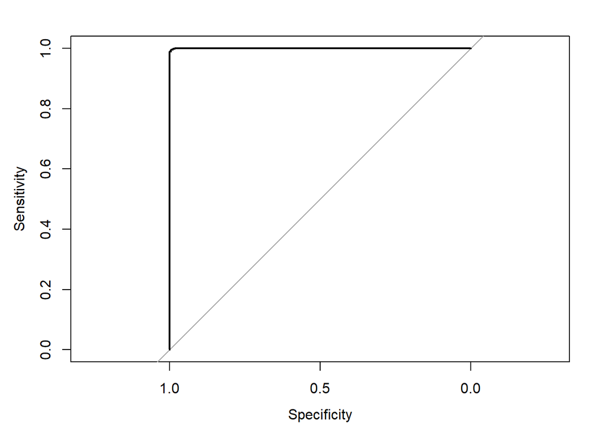

```r
plot(roccurve)
```

Manually calculation region of convergence for the test data

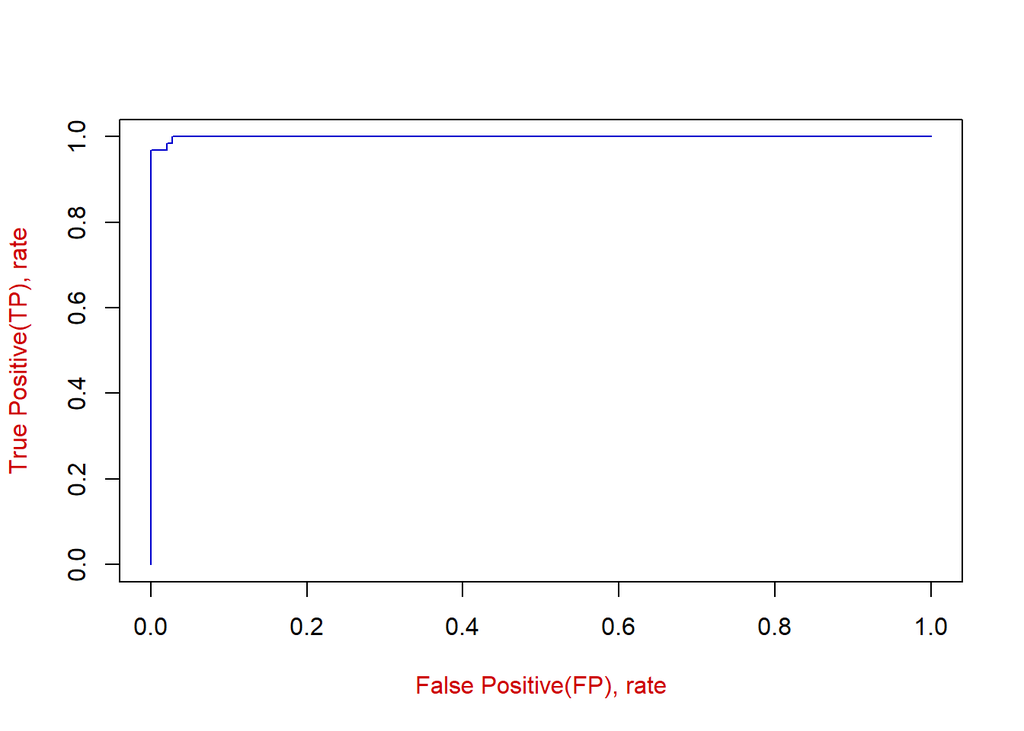

```r
L.R.prob <- predict(L.R.fit,newdata=bank.N_ts,type="response")
roc.pred <- prediction(L.R.prob,bank.N_ts_f.tor)
roc.tpr.fpr <- performance(roc.pred,measure="tpr", x.measure = "fpr")
plot(roc.tpr.fpr, col="blue3",col.lab="red3",
     xlab="False Positive(FP), rate",
     ylab="True Positive(TP), rate")
```

```r
roc.auc    <- performance(roc.pred,measure="auc")
Area_Under <- roc.auc@y.values[[1]]
Area_Under
```

```
## [1] 0.9992501
```

The area under the curve is 0.99.